# Data visualisation

## Data visualisation

### Introduction

- Example

```r
library(tidyverse)
head(mpg)
```

| manufacturer | model | displ | year | cyl | trans | drv | cty | hwy | fl | class |
| --- | --- | --- | --- | --- | --- | --- | --- | --- | --- | --- |
| audi | a4 | 1.8 | 1999 | 4 | auto(l5) | f | 18 | 29 | p | compact |
| audi | a4 | 1.8 | 1999 | 4 | manual(m5) | f | 21 | 29 | p | compact |
| audi | a4 | 2.0 | 2008 | 4 | manual(m6) | f | 20 | 31 | p | compact |
| audi | a4 | 2.0 | 2008 | 4 | auto(av) | f | 21 | 30 | p | compact |
| audi | a4 | 2.8 | 1999 | 6 | auto(l5) | f | 16 | 26 | p | compact |
| audi | a4 | 2.8 | 1999 | 6 | manual(m5) | f | 18 | 26 | p | compact |

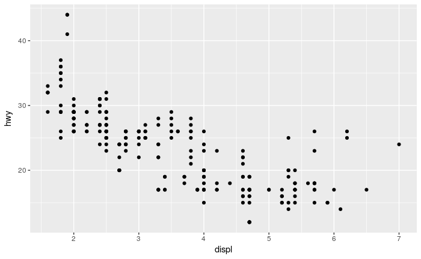

```r
ggplot(data=mpg)+
  geom_point(mapping = aes(x=displ,y=hwy))
```

The plot shows a negative relationship between engine size (displ) and fuel efficiency (hwy).

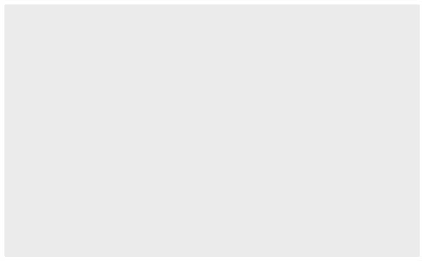

```r
ggplot(data=mpg)
```

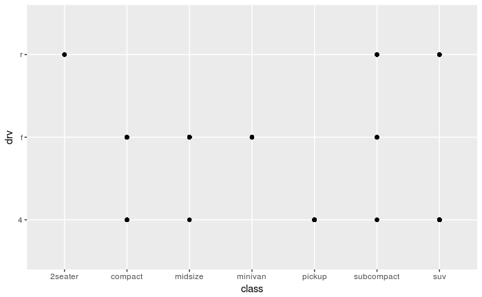

```r
ggplot(data=mpg)+
  geom_point(mapping = aes(x=class,y=drv))
```

### A graphing template

```
ggplot(data = <DATA>) +
  <GEOM_FUNCTION>(mapping = aes(<MAPPINGS>))
```

### Aesthetic mappings

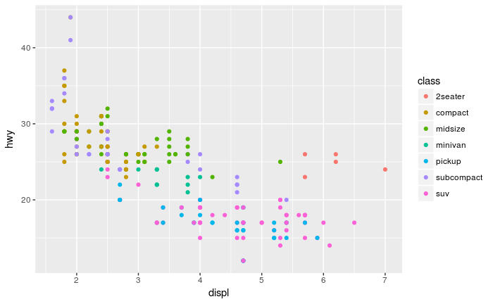

```r
ggplot(data = mpg)+
  geom_point(mapping = aes(x=displ,y=hwy,color=class))
```

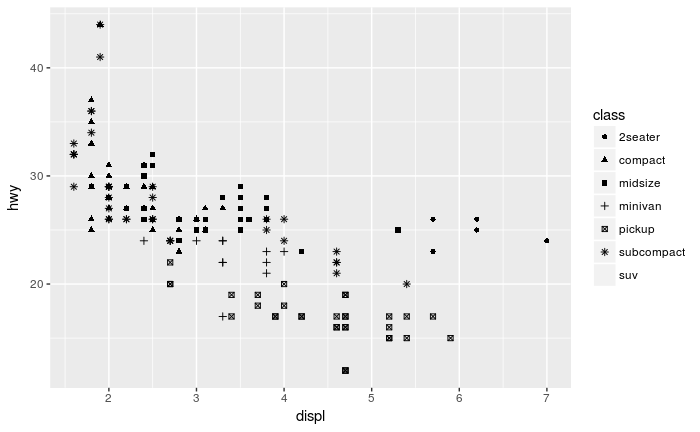

```r
ggplot(data = mpg)+
  geom_point(mapping = aes(x=displ,y=hwy,shape=class))
```

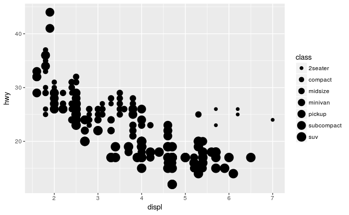

```r
ggplot(data = mpg)+
  geom_point(mapping = aes(x=displ,y=hwy,size=class))
```

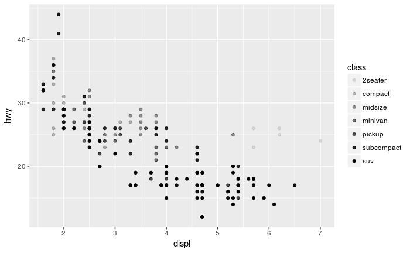

```r
ggplot(data = mpg)+
  geom_point(mapping = aes(x=displ,y=hwy,alpha=class))
```

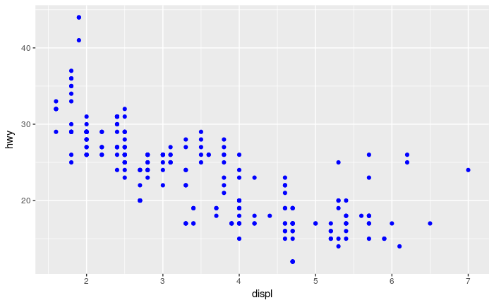

```r
ggplot(data = mpg)+
  geom_point(mapping = aes(x=displ,y=hwy),color="blue")
```

What happened to the SUVs? ggplot2 will only use six shapes at a time. By default, additional groups will go unplotted when you use the shape aesthetic.

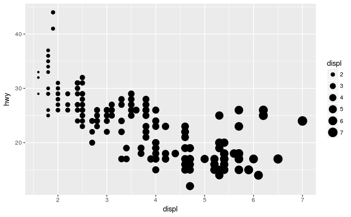

### Common problems

One common problem when creating ggplot2 graphics is to put the + in the wrong place: it has to come at the end of the line, not the start. In other words, make sure you haven’t accidentally written code like this:

```
ggplot(data = mpg)
+ geom_point(mapping = aes(x = displ, y = hwy))
```

### Facet

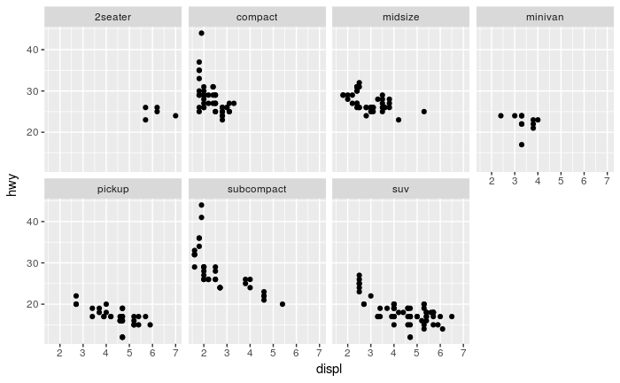

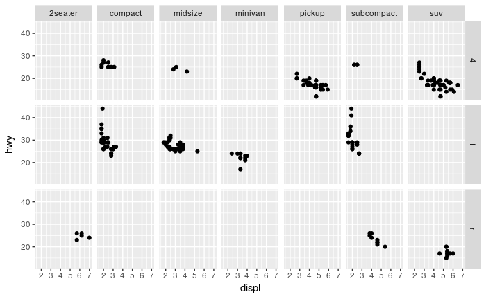

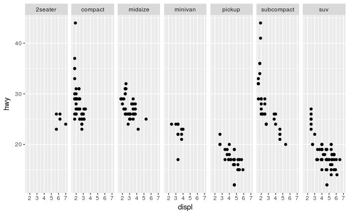

If you prefer to not facet in the rows or columns dimension, use a . instead of a variable name, e.g. + facet_grid(. ~ cyl). ### Exercise 1.

```r
ggplot(data = mpg) +
  geom_point(mapping = aes(x = displ, y = hwy)) +
  facet_grid(.~displ)

ggplot(data = mpg) +
  geom_point(mapping = aes(x = displ, y = hwy)) +
  facet_wrap(~displ)
```

[figure not shown]

### Geometric objects

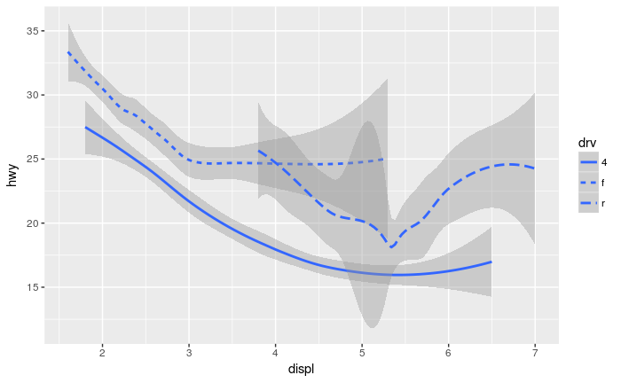

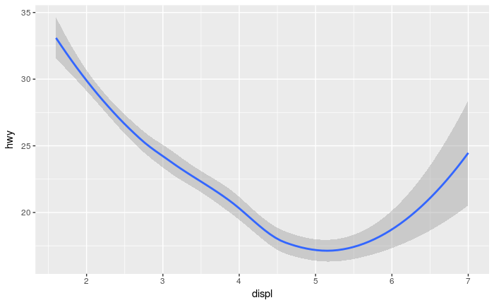

```r
ggplot(data=mpg)+
  geom_smooth(mapping = aes(x = displ, y = hwy))
```

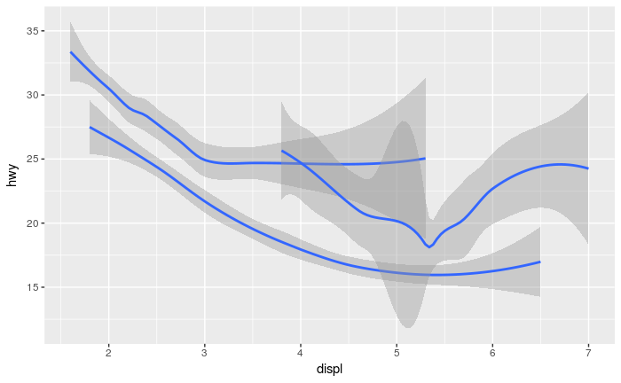

```r
ggplot(data=mpg)+
  geom_smooth(mapping = aes(x = displ, y = hwy,group=drv))
```

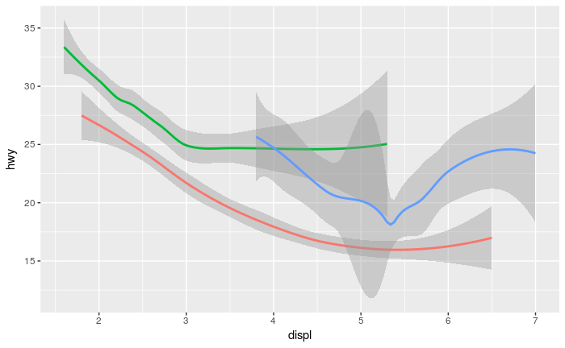

```r
ggplot(data=mpg)+
  geom_smooth(mapping = aes(x = displ, y = hwy,color=drv),
              show.legend = F)
```

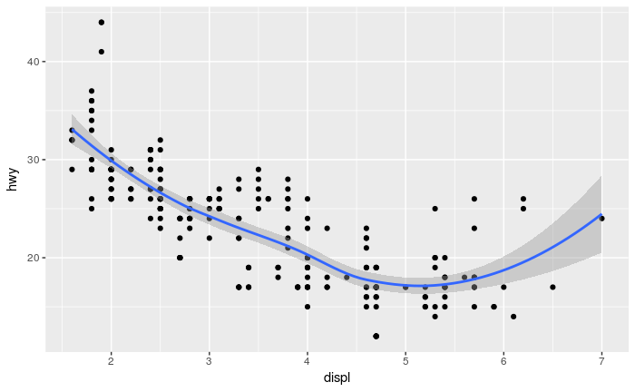

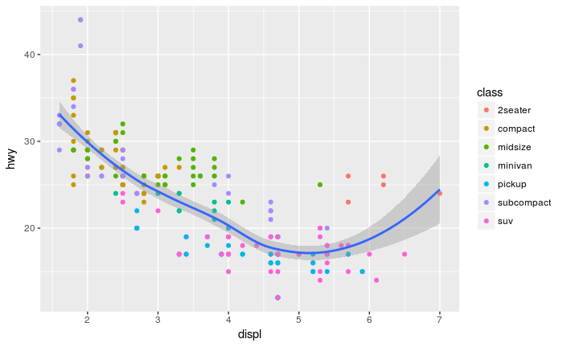

The local data argument in geom_smooth() overrides the global data argument in ggplot() for that layer only.

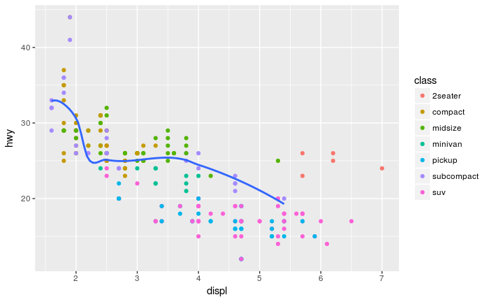

#### Exercises

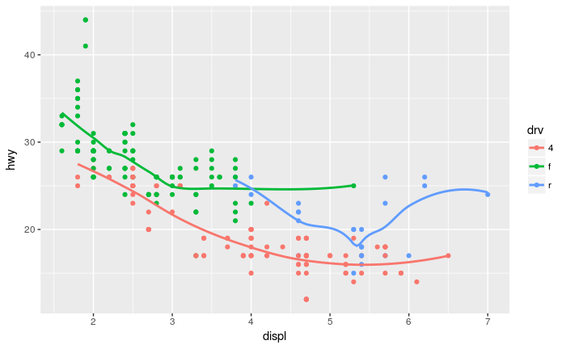

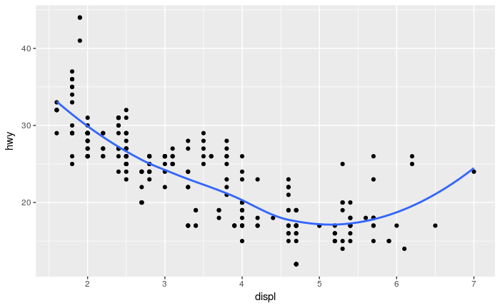

```r
ggplot(data = mpg, mapping = aes(x = displ, y = hwy)) +
  geom_point() +
  geom_smooth(se = FALSE)
```

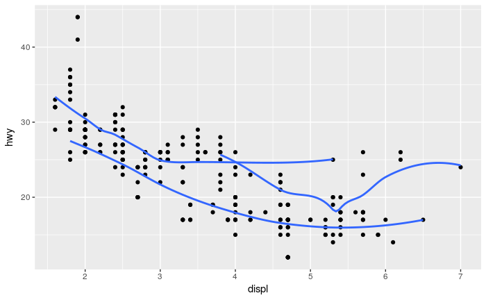

```r
ggplot(data = mpg, mapping = aes(x = displ, y = hwy)) +
  geom_point() +
  geom_smooth(mapping = aes(group=drv),se = FALSE)
```

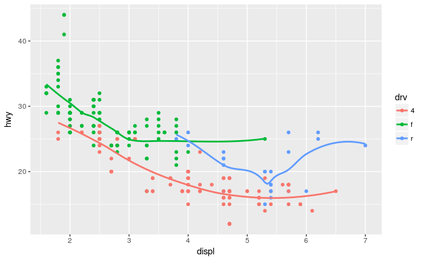

```r
ggplot(data = mpg, mapping = aes(x = displ, y = hwy,color=drv)) +
  geom_point() +
  geom_smooth(se = FALSE)
```

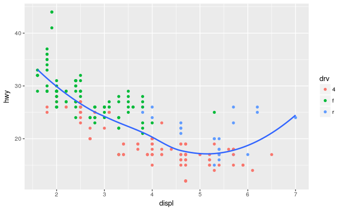

```r
ggplot(data = mpg, mapping = aes(x = displ, y = hwy)) +
  geom_point(mapping = aes(color=drv)) +
  geom_smooth(se = FALSE)
```

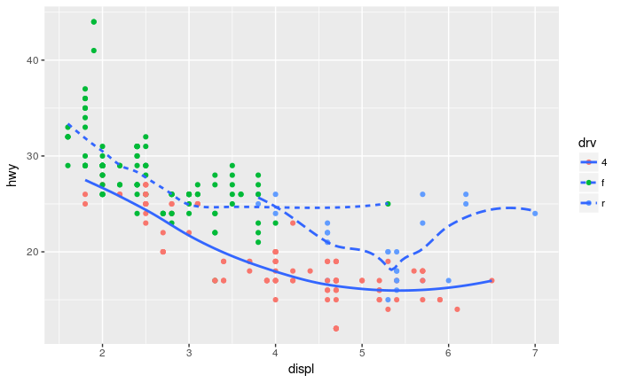

```r
ggplot(data = mpg, mapping = aes(x = displ, y = hwy)) +
  geom_point(mapping = aes(color=drv)) +
  geom_smooth(mapping = aes(linetype=drv),se = FALSE)
```

### Statistical transformations

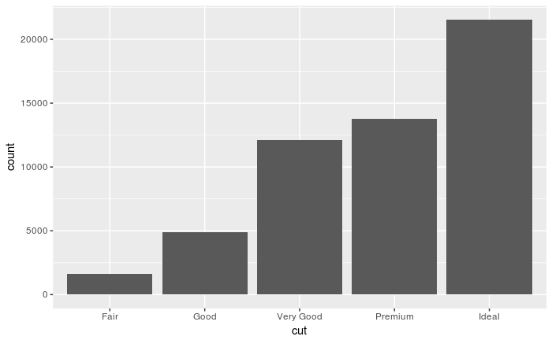

```r
ggplot(data = diamonds) +
  geom_bar(mapping = aes(x = cut))
```

Many graphs, like scatterplots, plot the raw values of your dataset. Other graphs, like bar charts, calculate new values to plot:

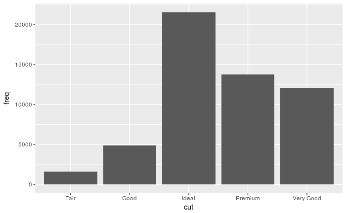

```r
demo <- tribble(
  ~cut,         ~freq,
  "Fair",       1610,
  "Good",       4906,
  "Very Good",  12082,
  "Premium",    13791,
  "Ideal",      21551
)
ggplot(data = demo) +
  geom_bar(mapping = aes(x = cut, y = freq), stat = "identity")
```

```r
ggplot(data = diamonds) +
  geom_bar(mapping = aes(x = cut, y = ..prop.., group = 1))
```

[output not shown]

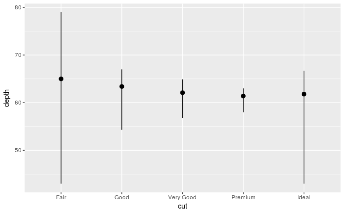

```r
ggplot(data = diamonds) +
  stat_summary(
    mapping = aes(x = cut, y = depth),
    fun.ymin = min,
    fun.ymax = max,
    fun.y = median
  )
```

#### Exercises

1. What is the default geom associated with stat_summary()? How could you rewrite the previous plot to use that geom function instead of the stat function?

```
ggplot(data = diamonds) +
  geom_col(mapping = aes(x=cut))
```

```r
ggplot(data = diamonds) +
  geom_bar(mapping = aes(x = cut, y = ..prop..,group=1))
```

[output not shown]

```r
ggplot(data = diamonds) +
  geom_bar(mapping = aes(x = cut, fill = color, y = ..prop..,group=1))
```

[output not shown]